# IODS Final assignment

#### 8.3.2017

#### tina.lauronen@helsinki.fi

## Abstract

This is a small exercise study about validation and hierarchies in cultural sections of European quality newspapers 1960-2010. The data is collected from seven newspapers from different European countries, coded using simple content analysis coding system and converted to a statistically analysable form.

In this study the data is analysed using multiple correspondence analysis. The variables used in the analysis cover some background information and information considering the content of the articles. Particularly the interest is in the art form discussed in the article and the format, the origin and the time horizon of the cultural product discussed. The aesthetic, commercial and political dimensions found from the articles are covered here as well.

As a result there are divisions of highbrow and popular culture and traditional and new culture found, as expected. Interestingly the aesthetic, commercial and political dimensions are visible too.

## Introduction

This is the final assignment of the course *Introduction to Open Data Science*, University of Helsinki, spring 2017. In this assignment I use the data of the research project *Cultural Distinctions, Generations and Change*. I am doing my doctoral studies in this project, shortly called [CuDiGE](http://blogs.helsinki.fi/cudige-project/). The project explores the classifications and valuations of culture and arts in European quality newspapers 1960-2010.

In this assignment I test a new way to approach the familiar data: I pick several interesting variables and use a new method for me, multiple correspondence analysis (MCA). Previously in this project we have been using logistic regression and multinomial logistic regression. The themes we have been working with this far have been related to differences between highbrow and popular culture, established and emerging cultural areas and cultural globalization (the last one being the focus of my dissertation). The publication list is available at the [project web site](http://blogs.helsinki.fi/cudige-project/publications-2/). This time I mix the themes a little bit and let an unsupervised method test if it finds the same kind of issues we have find. Also I include some less used and somewhat questionable variables (dimensional variables, see the presentation of the variables below) in the analysis just to see how they act with more familiar variables.

The aims of this assignment are experimental and quite wide: First I will try to find dimensions to support our earlier findings related to old and new; highbrow and popular; and domestic and foreign cultural products. Then I wish to find out how our aesthetic, commercial and political dimensions relate to those aspects. As background variables I keep the year and the newspaper in the analysis. The research questions are the following:

- What kinds of dimensions are found in MCA?
  - Highbrow vs. popular?
  - Old/traditional vs. new?
  - Domestic vs. foreign?
- How does aesthetic, commercial and political dimensions of the data appear related to dimensions found in MCA?

## The data

The data is collected from the cultural sections of European quality newspapers from 1960 to 2010. The newspapers are *ABC* and *El País* (hereafter *ABC/EP*) from Spain, *Dagens Nyheter* (*DN*) from Sweden, *The Guardian* (*GU*) from UK, *Helsingin Sanomat* (*HS*) from Finland, *Le Monde* (*LM*) from France and *Milliyet* (*MIL*) from Turkey. There are three randomly sampled weeks collected from each newspaper from ten-year intervals: 1960, 1970, 1980, 1990, 2000 and 2010.

The data is coded by eleven coders using ATLAS.ti software. The unit of analysis is individual article and the total N = 13,161. The coding system included more than 300 codes that covered 41 variables. After the coding there are several background variables added to data and it is converted to SPSS.

Now the data has been converted from SPSS to MS Office Excel and then modified in RSudio. Originally the data consisted of 13,161 observations and 373 variables (including several recodings). After selecting variables for these analyses and removing the observations with missing variables the data set includes 6,506 observations and nine variables. The data wrangling code is available in this [RScript file](https://github.com/tinalauronen/IODS-final/blob/master/Data/creating_cudige.R).

## The variables

The CuDiGe data is collected and coded in addition to investigate cultural hierarchies and valuations and their change in time. The coding system covered some technical issues like the size and illustration of the article, but mainly concentrated to the contents like the cultural area or art form discussed in the article. In these analyses the variables (and their values) are the following:

- **Year**
  - 1960; 1970; 1980; 1990; 2000; 2010
- **Newspaper**
  - ABC/EP; DN; GU; HS; LM; MIL
- **Art_form** referring to the primary cultural area discussed in the article. Here recoded into eight categories:
  - Literature; Classical music; Popular music; Film; TV; Theatre; Fine arts; Other
- **Artist_origin** referring to the geographical origin of the artist or piece of art (cultural product) discussed in the article. Here recoded into four categories:
  - Domestic; Other Europe; USA; Other
- **Artist_time** referring to the time horizon of the artist or piece of art (cultural product) discussed in the article. Here recoded into four categories:
  - Present; Post WW2; Pre WW2; Historical
- **Format** referring to the format of the piece of art
  - Live; Recording
- **Aesthetic** referring to the aesthetic dimension: explicit judgements on the good or poor quality of the piece of art treated in the article
  - Yes/No
- **Commercial** referring to the commercial dimension: explicit references to money or other economic indicators
  - Yes/No
- **Political** referring to the political dimension: explicit references to politics
  - Yes/No

```r
library(GGally)
library(ggplot2)
library(dplyr)
library(tidyr)
library(stringr)
library(corrplot)
library(FactoMineR)
```

```r
cudige <- read.csv("/Users/tlaurone/GitHub/tinalauronen/IODS-final/Data/cudige.csv")
cudige$Year <- factor(cudige$Year, levels = c(1960, 1970, 1980, 1990, 2000, 2010), labels = c("1960", "1970", "1980", "1990", "2000", "2010"))
```

## Descriptive statistics

First we take a look at the distribution on the variables. In Figure 1 there are the frequencies of the variables presented in alphabetical order.

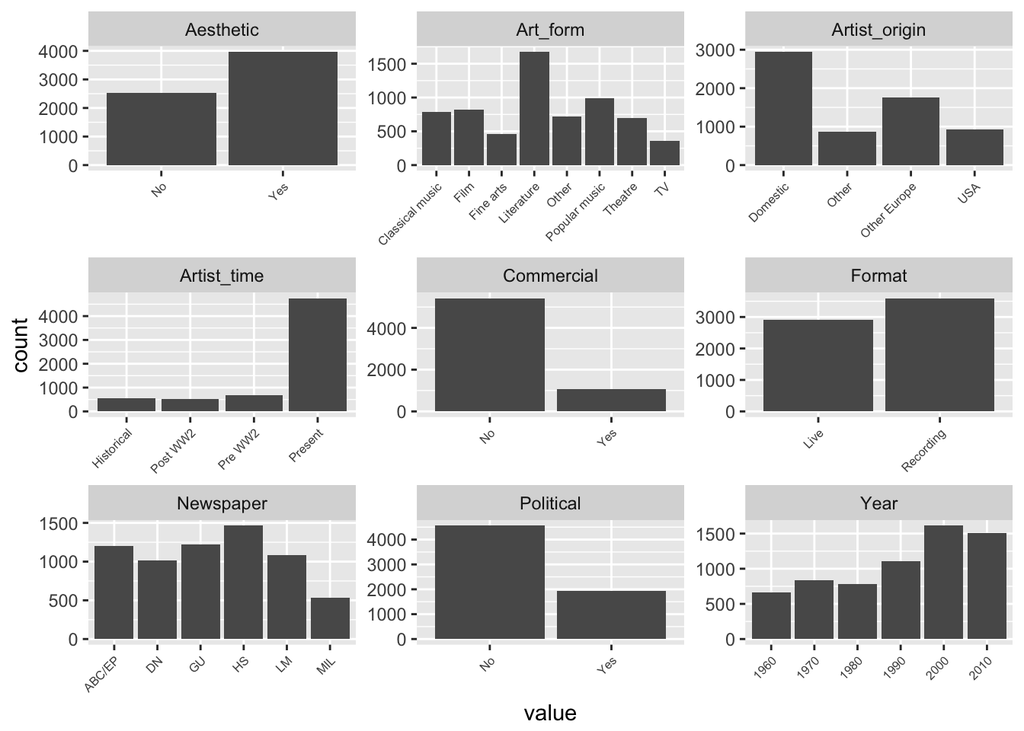

**Figure 1:** Distributions of the variables

```r
gather(cudige) %>% ggplot(aes(value)) + geom_bar() + theme(axis.text.x = element_text(angle = 45, hjust = 1, size = 6)) + facet_wrap("key", scales = "free")
```

The amount of articles increases in time, although 2010 there is a slight decrease visible. There are clear differences among the newspapers as well, the smallest *MIL* includes here only a little more than 500 articles while the largest *HS* includes almost 1,500 articles.

Of the dimensional variables the most common is *aesthetic dimension*. There is aesthetic dimension coded in almost 4,000 articles, while *political* is found in less than 2,000 and *commercial* only in 1,000 articles.

The same results are available in the summary table.

```r
summary(cudige, maxsum = 8)
```

```
##    Year       Newspaper               Art_form         Artist_origin
##  1960: 663   ABC/EP:1198   Classical music: 785   Domestic    :2945
##  1970: 834   DN    :1018   Film           : 826   Other       : 860
##  1980: 779   GU    :1217   Fine arts      : 463   Other Europe:1766
##  1990:1111   HS    :1463   Literature     :1676   USA         : 935
##  2000:1611   LM    :1081   Other          : 718
##  2010:1508   MIL   : 529   Popular music  : 986
##                            Theatre        : 692
##                            TV             : 360
##      Artist_time         Format     Aesthetic  Commercial Political
##  Historical: 559   Live     :2907   No :2540   No :5426   No :4555
##  Post WW2  : 516   Recording:3599   Yes:3966   Yes:1080   Yes:1951
##  Pre WW2   : 677
##  Present   :4754
##
##
##
##
```

## Multiple Correspondence Analysis (MCA)

Multiple correspondence analysis (MCA) is an unsupervised dimension reduction technique. It is suitable for nominal categorical variables.

## Results

MCA analysis is conducted here using all the variables selected to this assignment: the year, the newspaper, the art form, the format of the piece of art, the origin of the artist, the time horizon of the artist, aesthetic dimension, commercial dimension and political dimension. The full summary table of the analysis is available here. From the categories table we can see, that the v.tests for the categories of the variables are mainly superior to 2, which means that the results are significally different from 0.

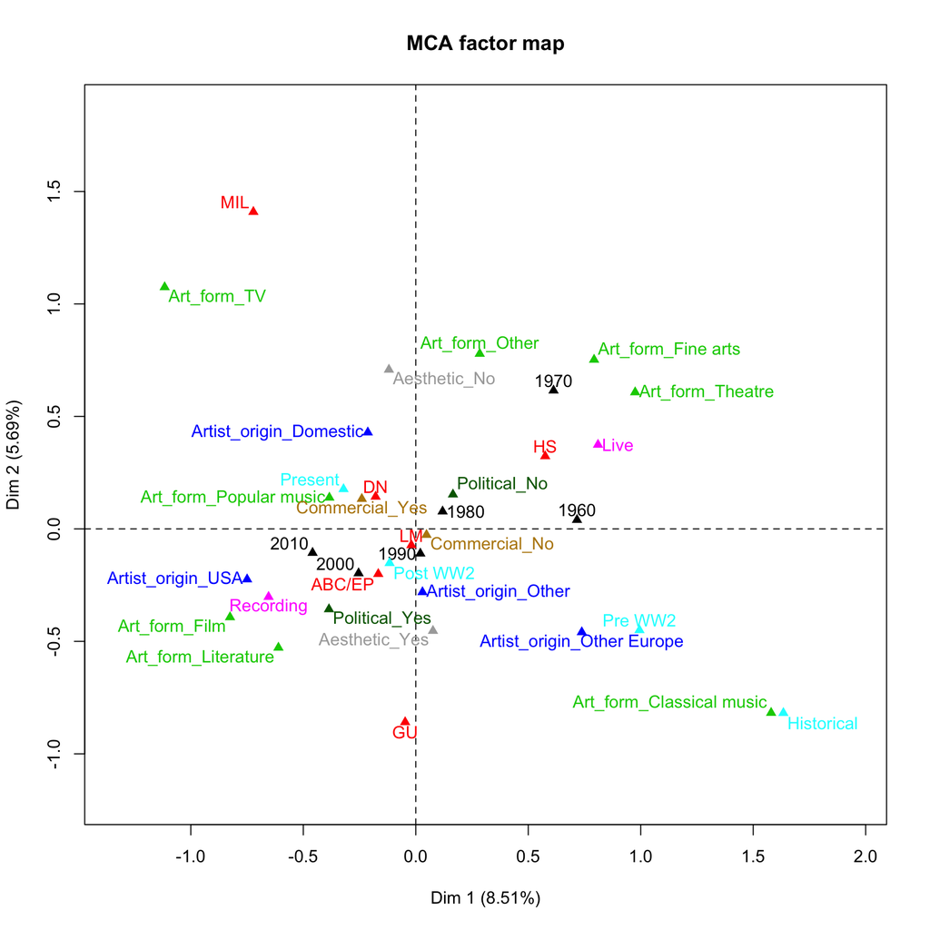

**Figure 2:** MCA analysis with the year, the newspaper, the art form, the format of the piece of art, the origin of the artist, the time horizon of the artist, aesthetic dimension, commercial dimension and political dimension. Data from 7 newspapers, N = 6,506.

```r
mca <- MCA(cudige, graph = FALSE)
plot(mca, invisible = c("ind"), habillage = "quali")
```

```r
summary(mca, nbelements = Inf, ncp = 2, file = "summary_mca.xls")
```

Dimensions 1 and 2 cover total 14.2 per cent of variance in this analysis. It is not much, but it is very common result in this kind of analysis. To interpret the dimensions 1 and 2 it is useful to take a look at to squared correlations between each variables and the dimensions.

| Categorical variables (eta2) | Dim.1 | Dim.2 |
| --- | --- | --- |
| Year | 0.167 | 0.064 |
| Newspaper | 0.127 | 0.334 |
| Art_form | 0.730 | 0.385 |
| Artist_origin | 0.249 | 0.158 |
| Artist_time | 0.409 | 0.103 |
| Format | 0.530 | 0.113 |
| Aesthetic | 0.009 | 0.321 |
| Commercial | 0.011 | 0.004 |
| Political | 0.064 | 0.055 |

Dimension 1 appears to be most affected by the art form. Other significant variables are the format and the time horizon of the cultural product. According to Figure 2 there seems to be division between highbrow and popular art forms. On the right side of the y axis (positive values on x axis representing dimension 1) there are classical highbrow art forms: classical music, theatre and fine arts and on the left side of the y axis (negative values on x axis) there are more popular art forms: TV, film, popular music - and literature. As in our previous research, the origin of the artist is linked to this division. Traditional highbrow culture is more often European and emerging popular culture comes more often from USA. The time horizon of the artist appears clear too: highbrow culture is older than popular culture. According to the format of the piece of art, it appears that highbrow culture is more often live performings than recordings.

Considering the year, 1990 appears in the middle of dimension 1 and recent times are on the left side of the y axis. This is understandable in a light of the rise of popular culture. When considering the newspapers there are some differences but rather small on dimension 1: HS appears to write more on traditional highbrow culture (which we know it is true) while DN and especially MIL write more about popular culture.

The dimensional variables are interesting as well, but the results are not as remarkable as with the other kind of variables. The aesthetical dimension is quite in the middle, only slightly more often appearing in the highbrow side of the y axis. Commercial dimension appears more often on the popular side of the y axis, but the difference is not very remarkable there either. Popular culture seems to be more often related to the political dimension than highbrow culture.

All in all there are at least slight differences among all the variables according to dimension 1. The most remarkable differences are the ones between the cultural areas or art forms, and mainly concentrated to the division on highbrow/popular, so it is relevant to interpret the dimension 1 as highbrow/popular dimension.

Dimension 2 is much more difficult to interpret. The most related variables are again the art form, then the newspaper and the aesthetical dimension. The largest values on the dimension (y axis) are related to newspaper MIL, art form TV and no aesthetical dimension. This brings out the question of the comparability of the Turkish newspaper in European traditional quality newspaper context: we already know that the results from MIL differ from the other newspapers: by the cultural products discussed in MIL being popular, being new, being domestic - and mainly considering TV. This analysis would result totally different if MIL was excluded (and we have been forced to exclude MIL from several studies).

```r
cudige5 <- read.csv("/Users/tlaurone/GitHub/tinalauronen/IODS-final/Data/cudige5.csv")
cudige5$Year <- factor(cudige5$Year, levels = c(1960, 1970, 1980, 1990, 2000, 2010), labels = c("1960", "1970", "1980", "1990", "2000", "2010"))
```

Just to compare the results I create a new dataset without the Turkish newspaper Milliyet. After the same modifying procedures as conducted with the original ones, this second data set consists of 5,977 observations and the same 9 variables. Figure 3 presents the same MCA analysis with this new data set. The full summary of the MCA is available here. From the categories table we can see, that the v.tests for the categories of the variables are again mainly superior to 2, which means that the results are significally different from 0.

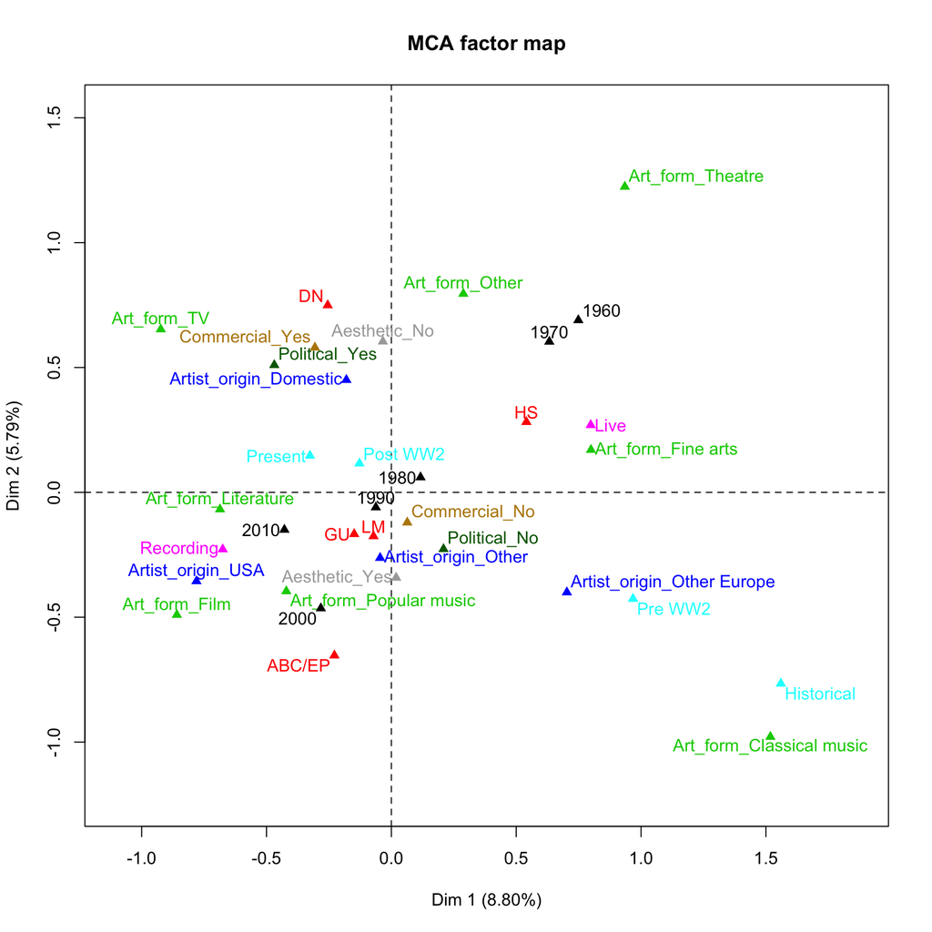

**Figure 3:** MCA analysis with the year, the newspaper, the art form, the format of the piece of art, the origin of the artist, the time horizon of the artist, aesthetic dimension, commercial dimension and political dimension. Data from 6 newspapers, N = 5,977.

```r
mca2 <- MCA(cudige5, graph = FALSE)
plot(mca2, invisible = c("ind"), habillage = "quali")
```

```r
summary(mca2, nbelements = Inf, ncp = 2, file = "summary_mca2.xls")
```

The dimensions 1 and 2 cover total 14.6 per cent of the variance, which is a little bit more than in the previous model. Again we take a look at the squared correlations between the variables and the dimensions 1 and 2.

| Categorical variables (eta2) | Dim.1 | Dim.2 |
| --- | --- | --- |
| Year | 0.174 | 0.157 |
| Newspaper | 0.099 | 0.212 |
| Art_form | 0.720 | 0.432 |
| Artist_origin | 0.240 | 0.162 |
| Artist_time | 0.399 | 0.089 |
| Format | 0.539 | 0.061 |
| Aesthetic | 0.001 | 0.207 |
| Commercial | 0.019 | 0.070 |
| Political | 0.098 | 0.116 |

Again dimension 1 appears to be connected to the art form, the format and the time horizon of the cultural product. In dimension 2 the most powerful variables are the art form, the newspaper and the aesthetic dimension, but they do not have as strong effect as the ones with dimension 1.

Dimension 1 could still be interpreted as division of highbrow/popular. On the other hand the time horizon of the cultural product is strongly connected to dimension 1, so it is possible to interpret it as division of traditional/new as well.

The second dimension appears problematic again. The art form matters, but not very clearly. Somehow the upper side of x axis (positive values on y axis) could be interpreted as visual art forms and the lower side non-visual (except at least partly film), but I do not find this explanation very strong.

One very interesting feature in dimension 2 is the role of the three dimensional variables: non-aesthetical but commercial and political appear on the upper side of the x axis, and aesthetical but non-commercial and non-political on the lower side of the x axis.

## Conclusions and discussion

As an exercise this assignment was really successful: I managed to handle a real, existing (and large) data with R, I used a method that I was not familiar before, and I found some useful results for our project for further analysis.

Previously we have been analysing our data mainly using binary or multinomial logistic regression, methods that can be defined as supervised methods. Now the same data has been analysed (in a rather experimental way) covering partly the same variables but by using unsupervised method. Regarding to the research questions of this study, the results were mainly expected.

The role of the Turkish paper Milliyet is difficult in some of the studies, because it differs radically from the other newspapers. Sometimes it is just easier to exclude it and conduct the analyses again, as in this case. On the other hand it had educational value, and when repeating the analysis the effects of one newspaper became visible.

As a main result of these analyses it is possible to say that the dimensions found support our previous results. There are dimensions in the data that reveal divisions between highbrow and popular culture, and old/traditional and new culture. The origin of the cultural product became remarkable mainly with those divisions: domestic and U.S. cultural products are new and popular compared to classical highbrow culture from Europe (and other parts of the world).

On the other hand we have been very careful to use our variables measuring aesthetic, commercial and political dimensions in the articles. These analyses showed that they could be useful as well. Especially it would be interesting to study further the finding considering non-aesthetic but commercial and political dimensions.

Considering the further studies the first step would be to conduct this kind of MCA with variables chosen more carefully. For example all the technical variables were excluded, and many content-related variables as well.